# data_exclusion

Paula Adamopoulos, Christopher Huebel, Helena Davies

15/03/2025

# 1 Setup

## 1.1 Clear workspace

```r
rm(list = ls())
```

Read in file with path to ilovedata channel on Teams Ensure that your credentials directory is correctly located

```r
source(file = "credentials/paths.R")
```

Add the add_numeric function - used to convert character variables into numeric variables. Add the sumscores function - used to generate sumscores Add the package_check function - used to install and load dependencies

```r
source(file = paste0(ilovedata_scripts, "functions/add_numeric.R"))
source(file = paste0(ilovedata_scripts, "functions/remove_duplicates.R"))
source(file = paste0(ilovedata_scripts, "functions/sumscores.R"))
source(file = paste0(ilovedata_scripts, "functions/package_check.R"))
source(file = paste0(ilovedata_scripts, "functions/imp_check.R"))
source(file = paste0(ilovedata_scripts, "functions/recode_check.R"))
```

## 1.2 Install packages

```r
#install.packages("ggformula")
#install.packages("tidyverse")
```

## 1.3 Load packages

```r
library(openxlsx)
library(gtsummary)
library(ggconsort)
library(tidyverse)
```

## 1.4 Retrieve the recent date

```r
date = Sys.Date()
date
```

```
[1] "2025-03-17"
```

## 1.5 Read in data

```r
dat <- read_rds(
  file = paste0(filepath_cleaned_data,"dat_variable_creation", date, ".rds"))
```

Psychiatric diagnoses

```r
psy_dx_factors <- c(
  "mhd.mdd",
  #"mhd.gad",
  #"mhd.social_anxiety",
  #"mhd.specific_phobia_",
  #"mhd.agoraphobia",
  #"mhd.panic_disorder",
  #"mhd.panic_attacks",
  #"mhd.bipolar_disorder",
  #"mhd.bdd",
  "mhd.an"
  #"mhd.atypical_an",
  #"mhd.bn",
  #"mhd.bed"
)
```

Analysis variables vector

```r
analysis_variables_vector <- c(
  "phq9.sum_score",
  "phq.Q9_suicidality_binary_numeric", # Suicidality
  "phq.Q9_suicidality_binary",
  "gender",
  "age",
  "bmi",
  "height_m",
  "ethnicity",
  "sexual_orientation",
  "dem.highest_education_collapsed",
  psy_dx_factors
)
```

# 2 Exclusion criteria

## 2.1 Exclusion table

-555 ‘Not applicable’ response from participant -666 Implausible response/value -777 Seen but not answered -888 Don’t know -999 Prefer not to answer/Prefer not to say

```r
dat %>%
  select(
    age,
    gender,
    ethnicity,
    sexual_orientation,
    height_m,
    bmi,
    dem.highest_education_collapsed,
    phq9.sum_score,
  "mhd.mdd",
  #"mhd.gad",
  #"mhd.social_anxiety",
  #"mhd.specific_phobia_",
  #"mhd.agoraphobia",
  #"mhd.panic_disorder",
  #"mhd.panic_attacks",
  #"mhd.bipolar_disorder",
  #"mhd.bdd",
  "mhd.an"
  #"mhd.atypical_an",
  #"mhd.bn",
  #"mhd.bed"
) %>%
  gtsummary::tbl_summary()
```

| **Characteristic** | **N = 55,799**<sup>1</sup> |
| --- | --- |
| age | 36 (26, 50) |
| Unknown | 755 |
| gender |  |
| Cis woman | 41,749 (77%) |
| Cis man | 10,840 (20%) |
| Non-binary | 955 (1.8%) |
| Trans man | 349 (0.6%) |
| Self-define | 339 (0.6%) |
| Trans woman | 134 (0.2%) |
| Unknown | 1,433 |
| ethnicity |  |
| White | 50,251 (94%) |
| Mixed | 1,471 (2.7%) |
| Asian, Asian British, Arab | 998 (1.9%) |
| Other | 570 (1.1%) |
| Black or Black British | 347 (0.6%) |
| Unknown | 2,162 |
| sexual_orientation |  |
| Heterosexual | 39,591 (74%) |
| Bisexual | 8,221 (15%) |
| Homosexual | 3,405 (6.3%) |
| Self-define | 1,795 (3.3%) |
| Asexual | 709 (1.3%) |
| Unknown | 2,078 |
| height_m | 1.68 (1.62, 1.73) |
| Unknown | 2,812 |
| bmi | 29 (25, 35) |
| Unknown | 4,510 |
| dem.highest_education_collapsed |  |
| None of the above | 1,462 (2.8%) |
| GCSEs/CSEs/O-levels or equivalent | 6,778 (13%) |
| NVQ/HND/HNC or equivalent | 4,593 (8.7%) |
| A-levels/AS-levels or equivalent | 11,939 (22%) |
| University | 28,326 (53%) |
| Unknown | 2,701 |
| phq9.sum_score | 12 (7, 18) |
| Unknown | 3,430 |
| mhd.mdd |  |
| Not MDD | 7,014 (13%) |
| MDD | 45,859 (87%) |
| Unknown | 2,926 |
| mhd.an |  |
| Not AN | 50,498 (96%) |
| AN | 2,174 (4.1%) |
| Unknown | 3,127 |

<sup>1</sup> Median (Q1, Q3); n (%)

# 3 Study cohorts

```r
study_cohorts <-
  dat %>%
  cohort_start("Consented") %>%
  # Define cohorts using named expressions --------------------
  # Notice that you can use previously defined cohorts in subsequent steps
  cohort_define(
    consented = .full,

    nogender = .full %>%
      drop_na(gender),

    missing_gender = anti_join(
      x = .full,
      y =  nogender,
      by = "ID"),

    nogender.noage = nogender %>%
      drop_na(age),

     missing_age = anti_join(
      x = nogender,
      y =  nogender.noage,
      by = "ID"),

    nogender.noage.noethnicity =
      nogender.noage %>%
      drop_na(ethnicity),

    missing_ethnicity = anti_join(
      x = nogender.noage,
      y =  nogender.noage.noethnicity,
      by = "ID"),

    nogender.noage.noethnicity.nosexuality =
      nogender.noage.noethnicity %>%
      drop_na(sexual_orientation),

    missing_sexuality = anti_join(
      x = nogender.noage.noethnicity,
      y =  nogender.noage.noethnicity.nosexuality,
      by = "ID"),


    nogender.noage.noethnicity.nosexuality.nobmiheight =
      nogender.noage.noethnicity.nosexuality %>%
      drop_na(
        bmi,
        height_m
        ),

    missing_bmiheight = anti_join(
      x = nogender.noage.noethnicity.nosexuality,
      y =  nogender.noage.noethnicity.nosexuality.nobmiheight,
      by = "ID"),

    nogender.noage.noethnicity.nosexuality.nobmiheight.noedu =
      nogender.noage.noethnicity.nosexuality.nobmiheight %>%
      drop_na(dem.highest_education_collapsed),

    missing_edu = anti_join(
      nogender.noage.noethnicity.nosexuality.nobmiheight,
      nogender.noage.noethnicity.nosexuality.nobmiheight.noedu,
      by = "ID"),

    nogender.noage.noethnicity.nosexuality.nobmiheight.noedu.nomhd =
      nogender.noage.noethnicity.nosexuality.nobmiheight.noedu %>%
      drop_na(
        psy_dx_factors
        ),

    missing_mhd = anti_join(
      nogender.noage.noethnicity.nosexuality.nobmiheight.noedu,
      nogender.noage.noethnicity.nosexuality.nobmiheight.noedu.nomhd,
      by = "ID")

  ) %>%
  # Provide text labels for subsamples ---------------------------
  cohort_label(
    consented =
      "Consented",
    nogender =
      "With gender",
    nogender.noage =
      "With gender, age",
    nogender.noage.noethnicity =
      "With gender, age, ethnicity",
    nogender.noage.noethnicity.nosexuality =
      "With gender, age, ethnicity, sexuality",
    nogender.noage.noethnicity.nosexuality.nobmiheight =
      "With gender, age, ethnicity, sexuality, BMI, height",
    nogender.noage.noethnicity.nosexuality.nobmiheight.noedu =
      "With gender, age, ethnicity, sexuality, BMI, height, education",
    nogender.noage.noethnicity.nosexuality.nobmiheight.noedu.nomhd =
      "With gender, age, ethnicity, sexuality, BMI, height, education, MHD",

    missing_gender = "Excluded: No gender",
    missing_age = "Excluded: No age",
    missing_ethnicity = "Excluded: No ethnicity",
    missing_sexuality = "Excluded: No sexuality",
    missing_bmiheight = "Excluded: No BMI or height",
    missing_edu = "Excluded: No education",
    missing_mhd = "Excluded No mental health diagnosis"
  )
```

# 4 Consort diagram (flow chart)

```r
study_consort <- study_cohorts %>%
  consort_box_add(
    name = "consented",
    x = 0,
    y = -10,
    label =  cohort_count_adorn(
      study_cohorts,
      .full)
  ) %>%
  consort_box_add(
    "missing_gender",
    x = 5,
    y = -15,
    label =  cohort_count_adorn(study_cohorts, missing_gender)
  ) %>%
  consort_box_add(
    name = "nogender",
    x = 0,
    y = -20,
    label =  cohort_count_adorn(
      study_cohorts,
      nogender)
  ) %>%
  consort_box_add(
    "missing_age",
    x = 5,
    y = -25,
    label =  cohort_count_adorn(study_cohorts, missing_age)
  ) %>%
  consort_box_add(
    name = "nogender.noage",
    x = 0,
    y = -30,
    label =  cohort_count_adorn(
      study_cohorts,
      nogender.noage)
  ) %>%
  consort_box_add(
    "missing_ethnicity",
    x = 5,
    y = -35,
    label =  cohort_count_adorn(
      study_cohorts,
      missing_ethnicity)
  ) %>%
  consort_box_add(
    name = "nogender.noage.noethnicity",
    x = 0,
    y = -40,
    label =  cohort_count_adorn(
      study_cohorts,
      nogender.noage.noethnicity)
  ) %>%
  consort_box_add(
    "missing_sexuality",
    x = 5,
    y = -45,
    label =  cohort_count_adorn(study_cohorts, missing_sexuality)
  ) %>%
  consort_box_add(
    name = "nogender.noage.noethnicity.nosexuality",
    x = 0,
    y = -50,
    label =  cohort_count_adorn(
      study_cohorts,
      nogender.noage.noethnicity.nosexuality)
  )  %>%
  consort_box_add(
    "missing_bmiheight",
    x = 5,
    y = -75,
    label =  cohort_count_adorn(study_cohorts, missing_bmiheight)
  ) %>%
  consort_box_add(
    name = "nogender.noage.noethnicity.nosexuality.nobmiheight",
    x = 0,
    y = -80,
    label =  cohort_count_adorn(
      study_cohorts,
      nogender.noage.noethnicity.nosexuality.nobmiheight)
  ) %>%
  consort_box_add(
    "missing_edu",
    x = 5,
    y = -85,
    label =  cohort_count_adorn(study_cohorts, missing_edu)
  ) %>%
  consort_box_add(
    name = "nogender.noage.noethnicity.nosexuality.nobmiheight.noedu",
    x = 0,
    y = -90,
    label =  cohort_count_adorn(
      study_cohorts,
      nogender.noage.noethnicity.nosexuality.nobmiheight.noedu)
  ) %>%
  consort_box_add(
    "missing_mhd",
    x = 5,
    y = -95,
    label =  cohort_count_adorn(study_cohorts, missing_mhd)
  ) %>%
  consort_box_add(
    name = "nogender.noage.noethnicity.nosexuality.nobmiheight.noedu.nomhd",
    x = 0,
    y = -100,
    label =  cohort_count_adorn(
      study_cohorts,
      nogender.noage.noethnicity.nosexuality.nobmiheight.noedu.nomhd)
  ) %>%
  consort_arrow_add(
    end = "nogender", end_side = "top", start_x = 0, start_y = -10
  ) %>%
  consort_arrow_add(
    end = "missing_gender", end_side = "left", start_x = 0, start_y = -15
  ) %>%
  consort_arrow_add(
    end = "nogender.noage", end_side = "top", start_x = 0, start_y = -20
  ) %>%
  consort_arrow_add(
    end = "missing_age", end_side = "left", start_x = 0, start_y = -25
  ) %>%
  consort_arrow_add(
    end = "nogender.noage.noethnicity", end_side = "top", start_x = 0, start_y = -30
  ) %>%
  consort_arrow_add(
    end = "missing_ethnicity", end_side = "left", start_x = 0, start_y = -35
  ) %>%
  consort_arrow_add(
    end = "nogender.noage.noethnicity.nosexuality", end_side = "top", start_x = 0, start_y = -40
  ) %>%
  consort_arrow_add(
    end = "missing_sexuality", end_side = "left", start_x = 0, start_y = -45
  ) %>%
  consort_arrow_add(
    end = "nogender.noage.noethnicity.nosexuality.nobmiheight", end_side = "top", start_x = 0, start_y = -70
  ) %>%
  consort_arrow_add(
    end = "missing_bmiheight", end_side = "left", start_x = 0, start_y = -75
  ) %>%
  consort_arrow_add(
    end = "nogender.noage.noethnicity.nosexuality.nobmiheight.noedu", end_side = "top", start_x = 0, start_y = -80
  ) %>%
  consort_arrow_add(
    end = "missing_edu", end_side = "left", start_x = 0, start_y = -85
  ) %>%
  consort_arrow_add(
    end = "nogender.noage.noethnicity.nosexuality.nobmiheight.noedu.nomhd", end_side = "top", start_x = 0, start_y = -90
  ) %>%
  consort_arrow_add(
    end = "missing_mhd", end_side = "left", start_x = 0, start_y = -95
  )
```

## 4.1 Figure

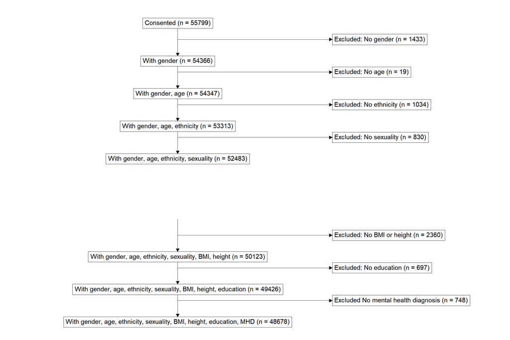

```r
study_consort %>%
  ggplot() +
  geom_consort() +
  theme_consort(margin_h = 20, margin_v = 1)
```

## 4.2 Save figure

+++ That’s currently not working. I have opened an issue on the GitHub https://github.com/tgerke/ggconsort/issues/26

# 5 Attrition variable

```r
names(study_cohorts$data)
```

```
 [1] ".full"
 [2] "consented"
 [3] "nogender"
 [4] "missing_gender"
 [5] "nogender.noage"
 [6] "missing_age"
 [7] "nogender.noage.noethnicity"
 [8] "missing_ethnicity"
 [9] "nogender.noage.noethnicity.nosexuality"
[10] "missing_sexuality"
[11] "nogender.noage.noethnicity.nosexuality.nobmiheight"
[12] "missing_bmiheight"
[13] "nogender.noage.noethnicity.nosexuality.nobmiheight.noedu"
[14] "missing_edu"
[15] "nogender.noage.noethnicity.nosexuality.nobmiheight.noedu.nomhd"
[16] "missing_mhd"
```

## 5.1 IDs after exclusion

```r
IDs_present <-
  as.vector(
  study_cohorts$data$nogender.noage.noethnicity.nosexuality.nobmiheight.noedu.nomhd$ID
  )
```

```r
dat_consented <- study_cohorts$data$consented
```

```r
dat_consented <- dat_consented %>%
  mutate(
    present =
      if_else(
        condition = ID %in% IDs_present,
        true = "Present",
        false = "Excluded",
        missing = NA_character_
      )
  )
```

# 6 Exclusion manually

## 6.1 gender

```r
dim(dat)
```

```
[1] 55799    40
```

```r
nogender <- dat %>%
  drop_na(gender)

missing_gender <- abs(nrow(nogender)-nrow(dat))
missing_gender
```

```
[1] 1433
```

1433 participants excluded due to missing gender.

## 6.2 age

```r
dim(nogender)
```

```
[1] 54366    40
```

```r
nogender.noage <- nogender %>%
  drop_na(age)

missing_age <- nrow(nogender.noage)-nrow(nogender)
missing_age
```

```
[1] -19
```

19 participants excluded due to missing age.

## 6.3 ethnicity

```r
dim(nogender.noage)
```

```
[1] 54347    40
```

```r
nogender.noage.noethnicity <-
  nogender.noage %>%
  drop_na(ethnicity)

missing_ethnicity <-
  nrow(nogender.noage.noethnicity) -
  nrow(nogender.noage)

missing_ethnicity
```

```
[1] -1034
```

1034 participants excluded due to missing ethnicity.

## 6.4 sexual orientation

```r
dim(nogender.noage.noethnicity)
```

```
[1] 53313    40
```

```r
nogender.noage.noethnicity.nosexuality <-
  nogender.noage.noethnicity %>%
  drop_na(sexual_orientation)

missing_sexuality <-
  nrow(nogender.noage.noethnicity.nosexuality) -
  nrow(nogender.noage.noethnicity)

missing_sexuality
```

```
[1] -830
```

830 participants excluded due to missing sexual orientation.

## 6.5 Exclusion BMI or height

```r
dim(nogender.noage.noethnicity.nosexuality)
```

```
[1] 52483    40
```

```r
nogender.noage.noethnicity.nosexuality.nobmiheight <-
  nogender.noage.noethnicity.nosexuality %>%
  drop_na(
    bmi,
    height_m
    )

missing_bmi <-
  nrow(nogender.noage.noethnicity.nosexuality.nobmiheight) -
  nrow(nogender.noage.noethnicity.nosexuality)

missing_bmi
```

```
[1] -2360
```

2360 participants excluded due to missing bmi.

## 6.6 education

```r
dim(nogender.noage.noethnicity.nosexuality.nobmiheight)
```

```
[1] 50123    40
```

```r
nogender.noage.noethnicity.nosexuality.nobmiheight.noedu <-
  nogender.noage.noethnicity.nosexuality.nobmiheight %>%
  drop_na(dem.highest_education_collapsed)

missing_edu <-
  nrow(nogender.noage.noethnicity.nosexuality.nobmiheight.noedu) -
  nrow(nogender.noage.noethnicity.nosexuality.nobmiheight)

missing_edu
```

```
[1] -697
```

697 participants excluded due to missing education.

## 6.7 mhd

```r
dim(nogender.noage.noethnicity.nosexuality.nobmiheight.noedu)
```

```
[1] 49426    40
```

```r
nogender.noage.noethnicity.nosexuality.nobmiheight.noedu.nomhd<- nogender.noage.noethnicity.nosexuality.nobmiheight.noedu %>%
  drop_na(
    all_of(psy_dx_factors)
  )

missing_mhd <-
  nrow(nogender.noage.noethnicity.nosexuality.nobmiheight.noedu.nomhd) -
  nrow(nogender.noage.noethnicity.nosexuality.nobmiheight.noedu)

missing_mhd
```

```
[1] -748
```

748 participants excluded due to missing mhd.

```r
nrow(nogender.noage.noethnicity.nosexuality.nobmiheight.noedu.nomhd)
```

```
[1] 48678
```

## 6.8 Final

Final *n* = 48678

Copy tibble after exclusion

```r
dat_after_exclusion <-
  nogender.noage.noethnicity.nosexuality.nobmiheight.noedu.nomhd
nrow(dat_after_exclusion)
```

```
[1] 48678
```

# 7 Write rds file

```r
dat_after_exclusion %>%
  write_rds(
  file =  paste0(filepath_cleaned_data,"dat_after_exclusion", date, ".rds")
  )
```

dat_consented

```r
dat_consented %>%
  write_rds(
  file =  paste0(filepath_cleaned_data,"dat_consented_attrition", date, ".rds")
  )
```